# Case Study 2

Ahmed Awadallah

1/31/2022

## Executive Summary and Introduction

This is an R Markdown document detailing an in depth analysis on the employee data set. The employee dataset was explored in order to provide the requested key insights on attrition and job role trends. Additionally, I provide some interesting trends I found along the way. Lastly models were generated in order to predict salary as well as likelihood of attrition.

## Top 3 Contributors to Attrition

#### Age

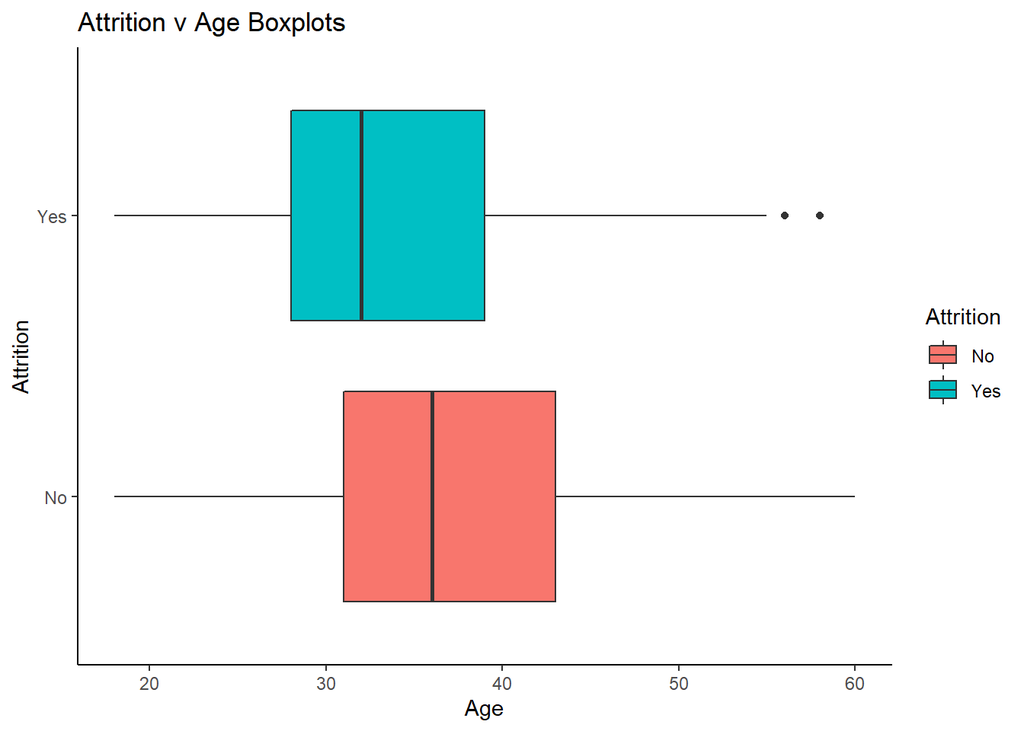

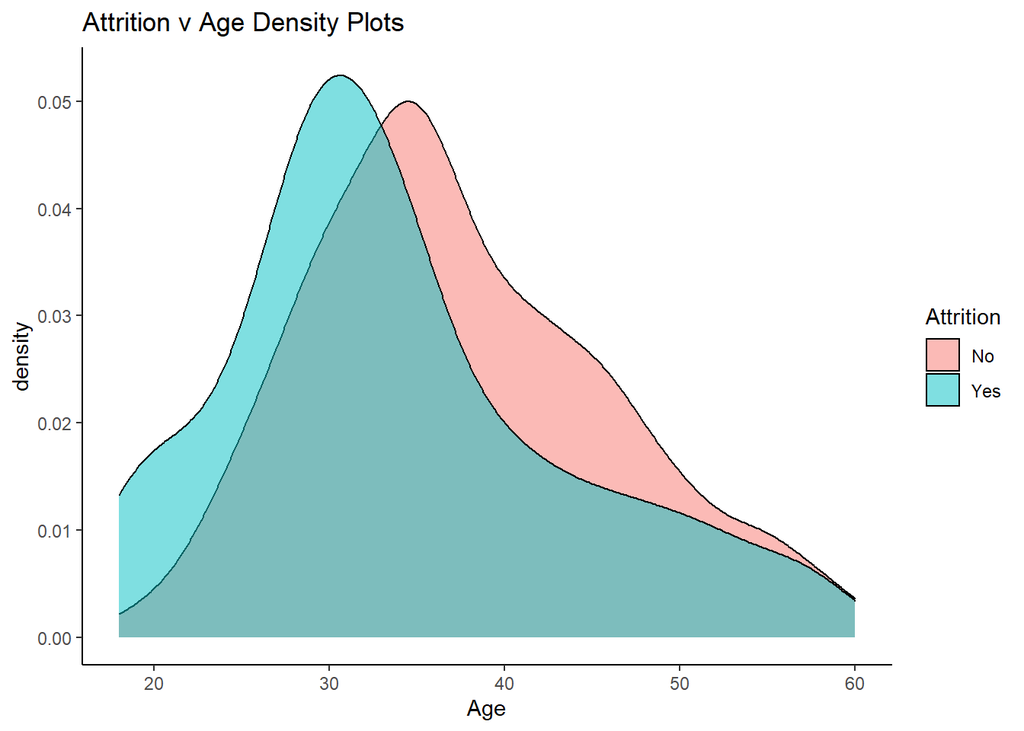

This data provides overwhelming evidence that the mean age of those who leave the company versus those who stay are different.(P = 5.05E-05) We are 95% confident that those who stay are between 1.9 to 5.35 years older than those who leave.

#### Monthly Income

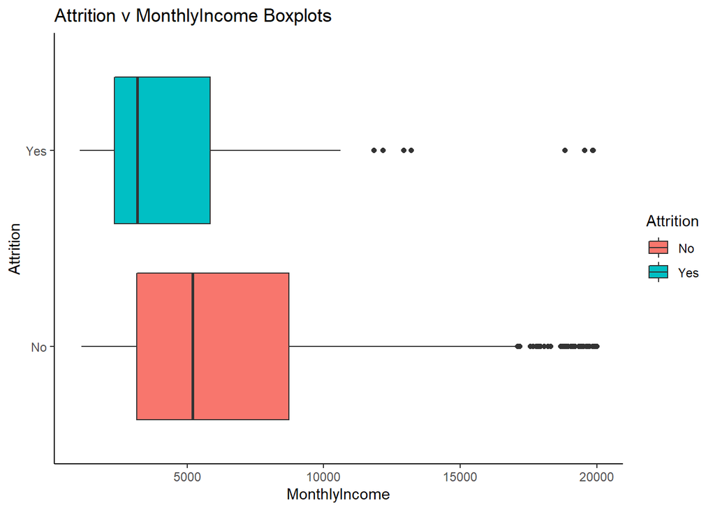

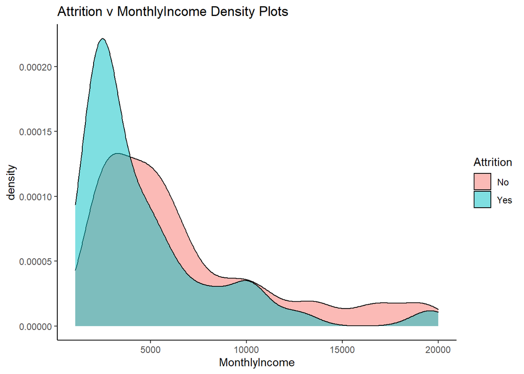

This data provides overwhelming evidence that the mean monthly income of those who leave the company versus those who stay are different. (P = 2.412E-07) We are 95% confident that those who stay have a monthly income that is 1220USD to 2654USD larger than those who leave.

#### Overtime

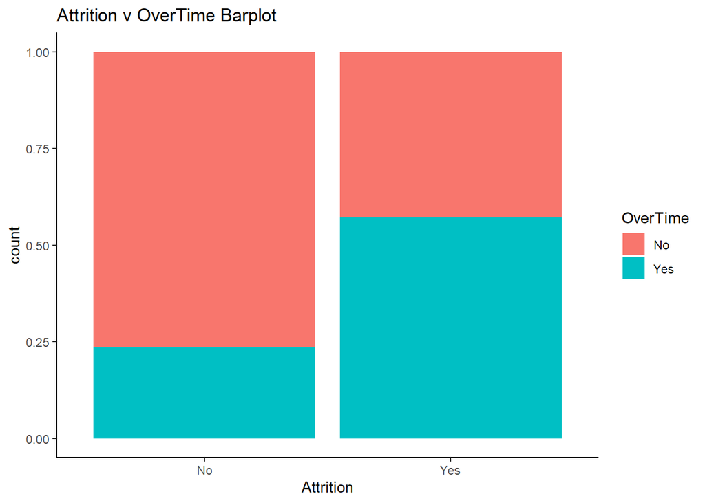

This data provides overwhelming evidence that these two variables are dependent. (P = 2.333E-15)

## Interesting Job Role Specific Trends

#### Job Role and Age

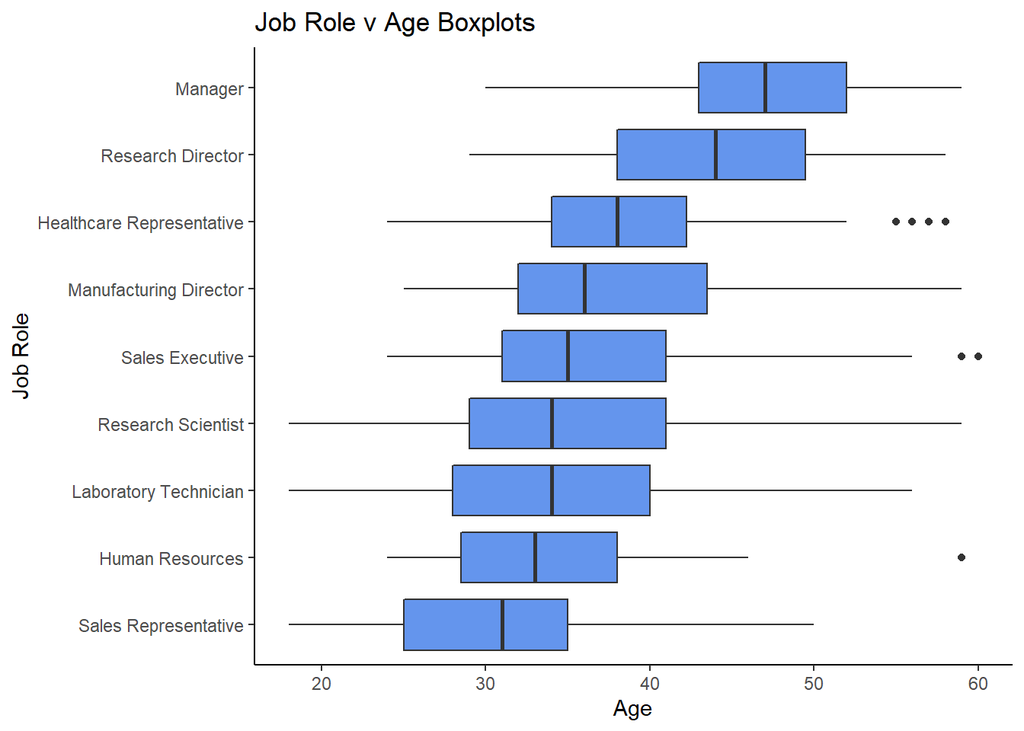

#### Job Role and Education

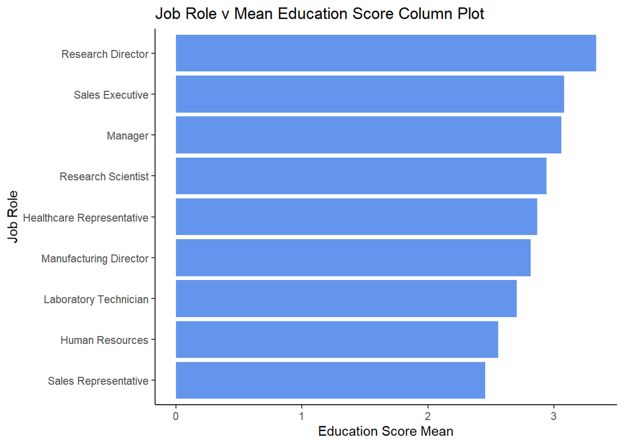

#### Job Role and Education Field

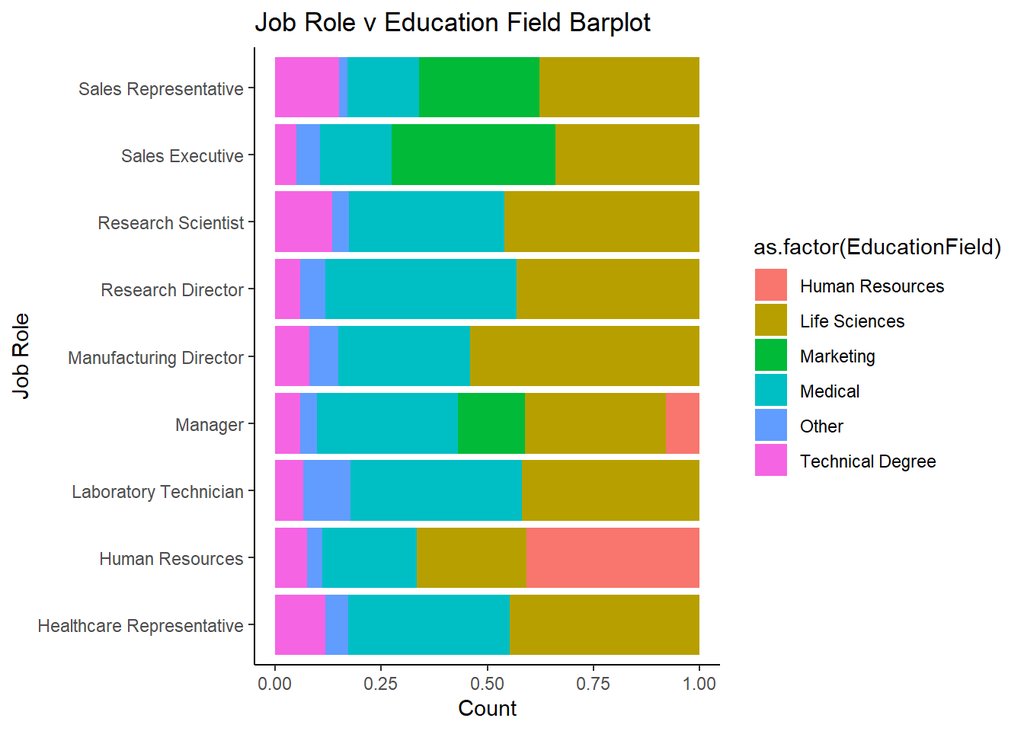

#### Job Role and Monthly Income

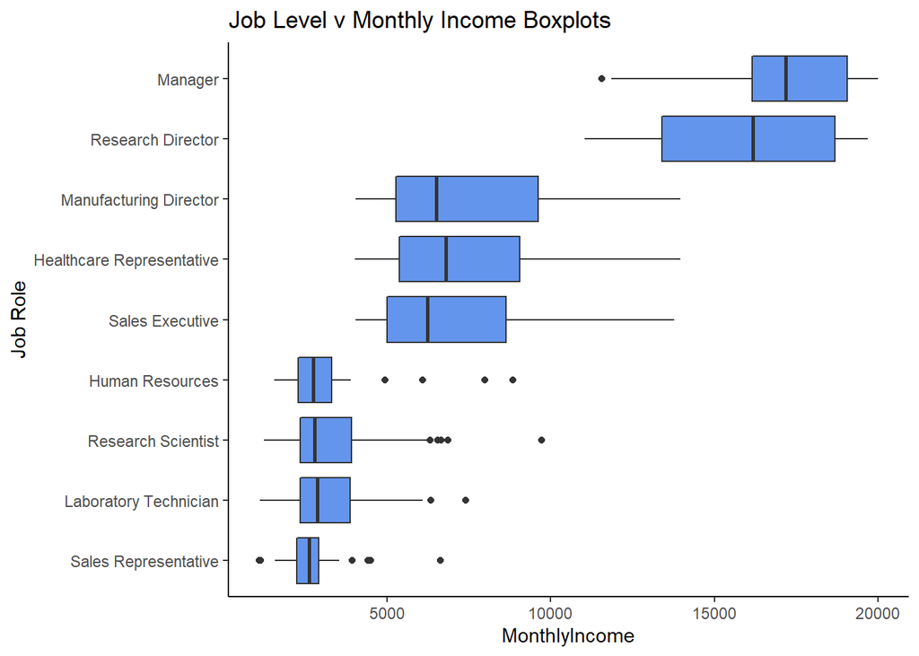

## Bonus Analysis

#### Department and MonthlyIncome

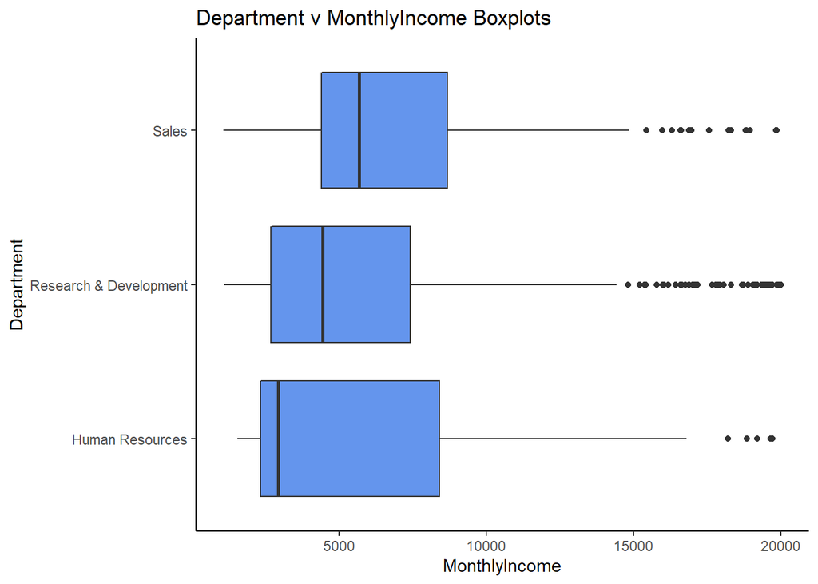

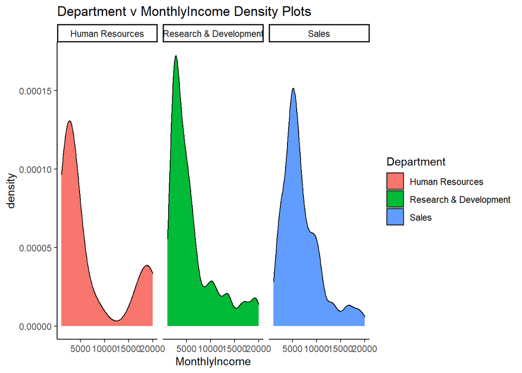

#### MonthlyIncome and Years at Company

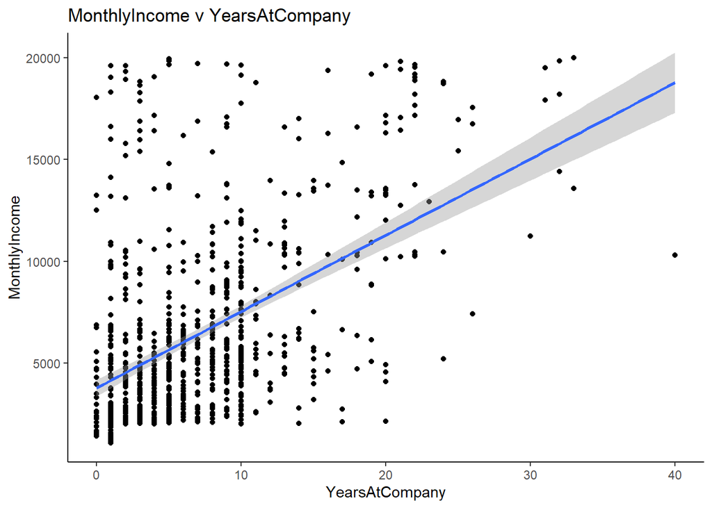

There is overwhelming evidence of a positive linear relationship between monthly income and years at the company.(P < 2E-16). We are 95% confident that for every year at the company the increase in monthly income is somewhere between 330USD to 419USD.

Take note on this plot that there are people who barely began working at the company yet started at a large income.

#### MonthlyIncome and Total Years Working

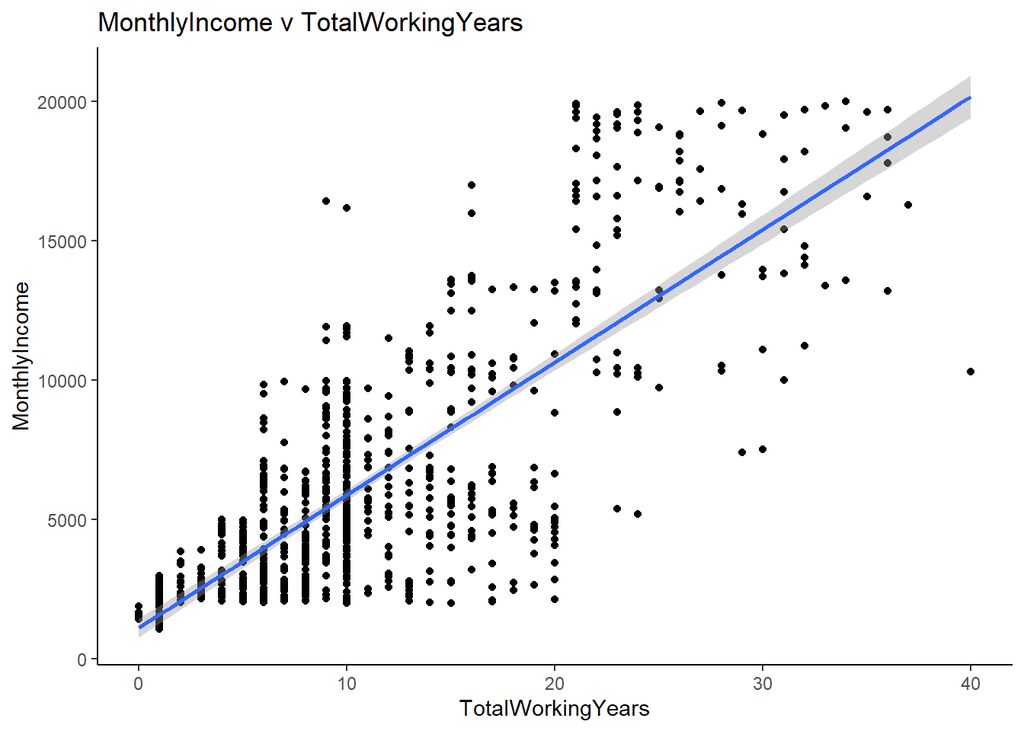

There is overwhelming evidence of a positive linear relationship between monthly income and total working years.(P < 2E-16). We are 95% confident that for every year working the increase in monthly income is somewhere between 450USD to 501USD.

Take not now on this plot how at the start of a career the Income is low for all.

Both relationships increase per year but total working is 26% more per year.

This seems to indicate that if employees want to increase their own income at a faster rate they are better off leaving the company.

## Attrition Prediction Model

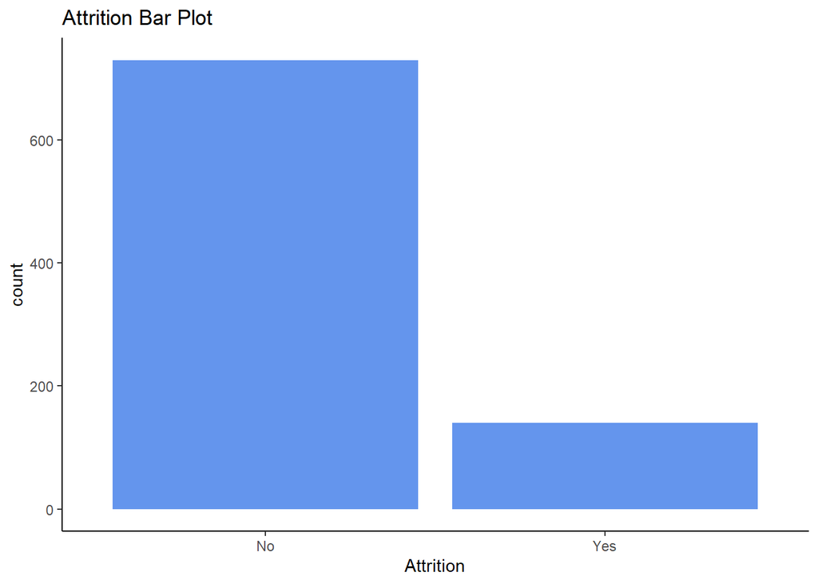

#### KNN Performance

```
## Confusion Matrix and Statistics
##
##
## clsf_rep No Yes
##      No  53   7
##      Yes 16  11
##
##                Accuracy : 0.7356
##                  95% CI : (0.6302, 0.8245)
##     No Information Rate : 0.7931
##     P-Value [Acc > NIR] : 0.92389
##
##                   Kappa : 0.3201
##
##  Mcnemar's Test P-Value : 0.09529
##
##             Sensitivity : 0.7681
##             Specificity : 0.6111
##          Pos Pred Value : 0.8833
##          Neg Pred Value : 0.4074
##              Prevalence : 0.7931
##          Detection Rate : 0.6092
##    Detection Prevalence : 0.6897
##       Balanced Accuracy : 0.6896
##
##        'Positive' Class : No
##
```

#### Forest Performance

```
## Confusion Matrix and Statistics
##
##
## pred_forest No Yes
##         No  61   3
##         Yes 14   9
##
##                Accuracy : 0.8046
##                  95% CI : (0.7057, 0.8819)
##     No Information Rate : 0.8621
##     P-Value [Acc > NIR] : 0.95079
##
##                   Kappa : 0.4067
##
##  Mcnemar's Test P-Value : 0.01529
##
##             Sensitivity : 0.8133
##             Specificity : 0.7500
##          Pos Pred Value : 0.9531
##          Neg Pred Value : 0.3913
##              Prevalence : 0.8621
##          Detection Rate : 0.7011
##    Detection Prevalence : 0.7356
##       Balanced Accuracy : 0.7817
##
##        'Positive' Class : No
##
```

## Monthly Income Prediction Model

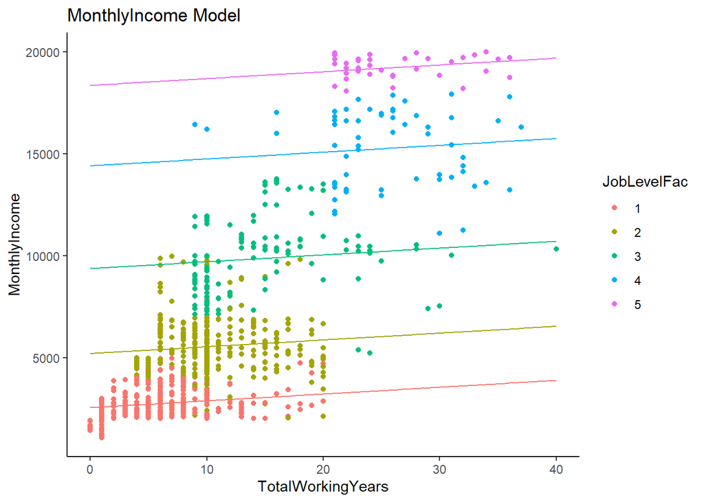

Average RMSE of this model on the test set was 1257.59.